# Inside Context Memory

> This notebook focuses on context memory Inside the rooms.

# 1 Overview of the data

The rooms were separated into *Familiar* and *Novel* groups. Participants explored the *Familiar* group at the beginning of the experiment. In the encoding task, they visisted both *Familiar* and *Novel* groups. Their context memory (i.e., in which room they saw the item) was tested in the memory test the next day of the encoding task. **Novelty benefits** on the context memory are examined by comparing the memory performance between the *Familiar* and *Novel* groups.

Participants were also asked to rate how curious they felt about the room. The higher the rating is means they felt more curious about the room. Context memory as a function of curiosity rating was also examined for **curiosity benefits**.

Questionnaires on personal traits regarding curiosity were also administered to participants before the encoding task (i.e., PC and EC). Scores on these questionnaires might be able to predict the context memory or its relationship with curiosity rating.

# 2 Individual performance

## 2.1 An overview of individual context memory performance as a function of room.

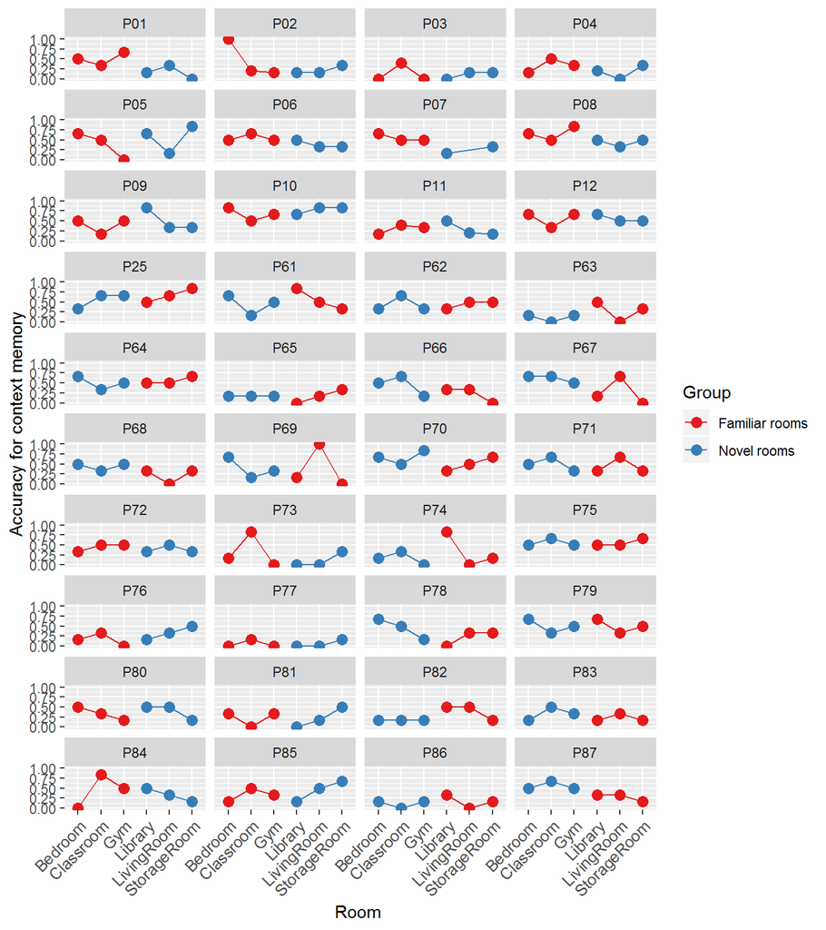

Figure 1. Mean accuracy for context memory respectively for each room and each individual participant.

# 3 Novelty Benefits

We predicted that the context memory should be better for the *novel* rooms than for the *familiar* rooms.

## 3.1 Compare mean accuracy between *novel* and *familiar* rooms

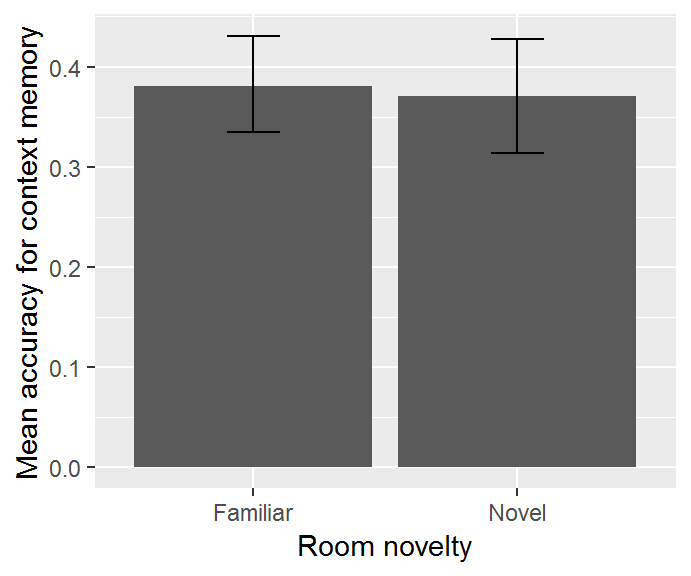

Figure 2. Mean accuracy for context memory respectively for Familiar and Novel rooms.

Against our prediction, the mean accuracy of context memory is higher in the *familiar* rooms than in the *novel* rooms.

```
##
##  Paired t-test
##
## data:  MeanCorrContextAccuracy by Group
## t = 0.38322, df = 39, p-value = 0.7036
## alternative hypothesis: true difference in means is not equal to 0
## 95 percent confidence interval:
##  -0.04218676  0.06190898
## sample estimates:
## mean of the differences
##             0.009861111
```

## 3.2 Context memory as a function of item order

### 3.2.1 Visualise the data

#### 3.2.1.1 Nonlinear

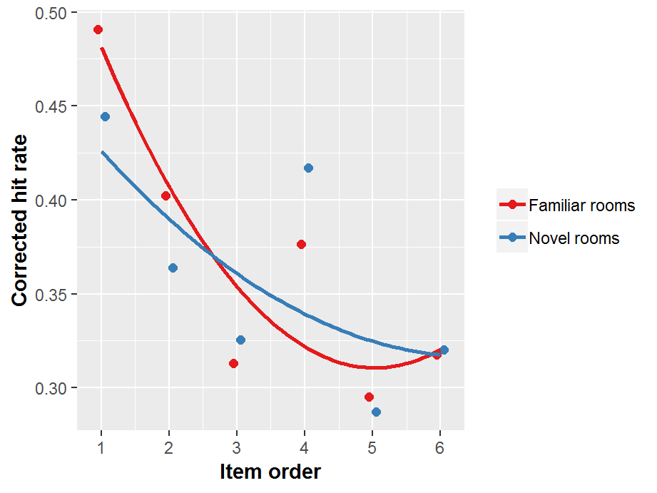

Figure 3. Mean accuracy of context memory for items at each order (i.e., 1st, 2nd, 3rd, etc), respectively for familiar and novel rooms.

#### 3.2.1.2 Linear

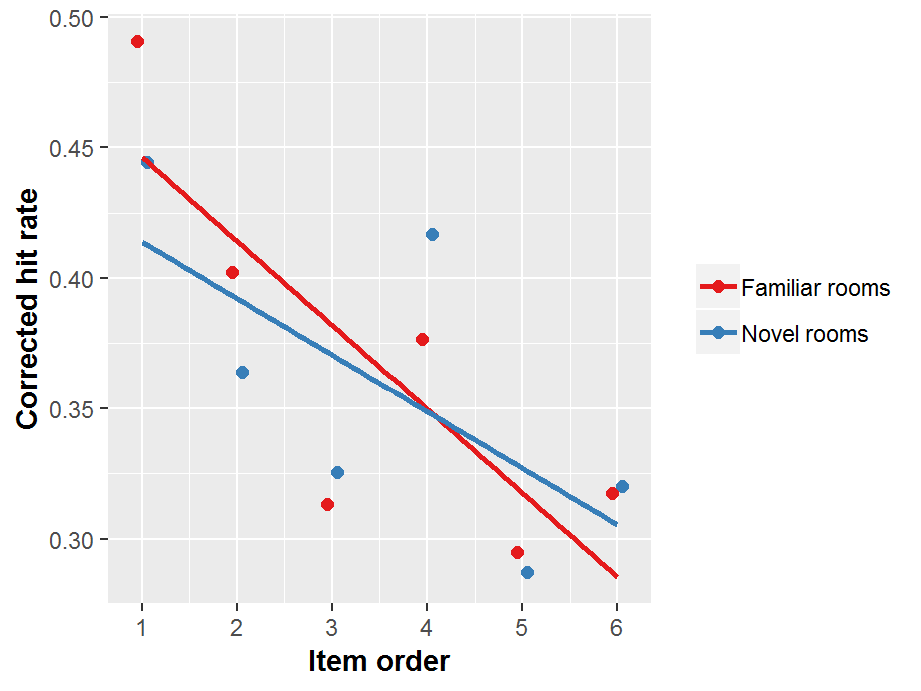

### 3.2.2 Testing novelty effect as a function of item order by fitting mixed models

Build models with context memory accuracy as $y$ and then examine effects of item order and novelty by comparing the models.

- `baseline.context` is the model with only an intercept.
- `order.model.linear.1` is the model with $\small ItemOrder$ included, showing the effects of item order.
- `order.model.linear.2` is the model allowing the slope (i.e., relationship between context memory and item order) varying across participants.
- `order.model.quad.1` and `order.model.quad.2` repectively included $\small ItemOrder^2$ and related random effects.
- `novelty.model.1` is the model with $\small Group$ (i.e., *familiar* and *novel* rooms) included, examining the effects of novelty of the rooms on the intercept (i.e., mean context memory accuracy at the 1st order or overall if no difference in slope).
- `novelty.model.2` is the model with interaction between $\small Group$ and $\small ItemOrder$ included, examining the effects of novelty on how context memory accuracy changes as a function of item order.
- `novelty.model.3` included interaction between $\small Group$ and $\small ItemOrder^2$ for inestigating whether the pattern changes between *familiar* and *novel* groups.

```
##                      Model df       AIC      BIC    logLik   Test
## baseline.context         1  4 108.59443 125.2896 -50.29721
## order.model.linear.1     2  5  94.23822 115.1072 -42.11911 1 vs 2
## order.model.quad.1       3  6  93.79526 118.8380 -40.89763 2 vs 3
## novelty.model.1          4  7  95.73513 124.9516 -40.86756 3 vs 4
## novelty.model.2          5  8  97.09608 130.4864 -40.54804 4 vs 5
## novelty.model.3          6  9  98.51174 136.0758 -40.25587 5 vs 6
##                        L.Ratio p-value
## baseline.context
## order.model.linear.1 16.356207  0.0001
## order.model.quad.1    2.442960  0.1181
## novelty.model.1       0.060133  0.8063
## novelty.model.2       0.639048  0.4241
## novelty.model.3       0.584341  0.4446
```

No significant effects except item order.

### 3.2.3 Collapse the order

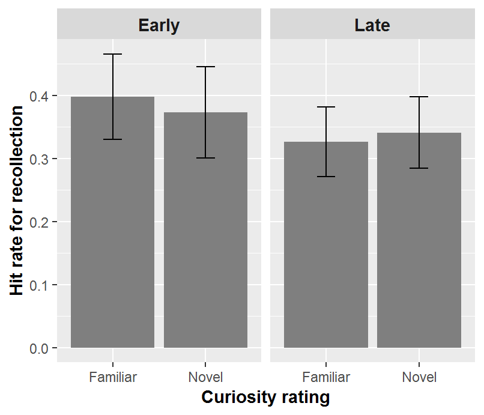

#### 3.2.3.1 Stats on it

```
##                  Model df       AIC       BIC   logLik   Test  L.Ratio
## baseline             1  5 -90.09071 -74.71484 50.04536
## noveltyModel         2  6 -88.12892 -69.67788 50.06446 1 vs 2 0.038212
## orderModel           3  7 -91.55908 -70.03286 52.77954 2 vs 3 5.430157
## interactionModel     4  8 -90.37692 -65.77553 53.18846 3 vs 4 0.817844
##                  p-value
## baseline
## noveltyModel      0.8450
## orderModel        0.0198
## interactionModel  0.3658
```

```
## Linear mixed-effects model fit by maximum likelihood
##  Data: Encoding.Recall.Old.Order.Novelty
##         AIC       BIC   logLik
##   -90.37692 -65.77553 53.18846
##
## Random effects:
##  Formula: ~1 | SubjectNo
##         (Intercept)
## StdDev:    0.127083
##
##  Formula: ~1 | Group %in% SubjectNo
##         (Intercept)
## StdDev:  0.05643828
##
##  Formula: ~1 | ItemOrderType %in% Group %in% SubjectNo
##         (Intercept)   Residual
## StdDev:   0.1297346 0.04644319
##
## Fixed effects: CorrContextAccuracy ~ Group + ItemOrderType + Group:ItemOrderType
##                                   Value  Std.Error DF   t-value p-value
## (Intercept)                   0.3981737 0.03134727 78 12.702022  0.0000
## GroupNovel                   -0.0246771 0.03372081 39 -0.731808  0.4687
## ItemOrderTypeLate            -0.0716636 0.03120490 78 -2.296551  0.0243
## GroupNovel:ItemOrderTypeLate  0.0395081 0.04413039 78  0.895258  0.3734
##  Correlation:
##                              (Intr) GrpNvl ItmOTL
## GroupNovel                   -0.538
## ItemOrderTypeLate            -0.498  0.463
## GroupNovel:ItemOrderTypeLate  0.352 -0.654 -0.707
##
## Standardized Within-Group Residuals:
##           Min            Q1           Med            Q3           Max
## -0.6341562861 -0.1835890409  0.0008171967  0.1744440448  0.8607104839
##
## Number of Observations: 160
## Number of Groups:
##                               SubjectNo
##                                      40
##                    Group %in% SubjectNo
##                                      80
## ItemOrderType %in% Group %in% SubjectNo
##                                     160
```

# 4 Curiosity Benefits

Here I checked how accurach of context memory changes as a function of curiosity rating. We hypothesised that the more curiosity the participant felt about the room (higher ratings) the better the context memory.

## 4.1 Mean accuracy of context memory as a function of curiosity rating

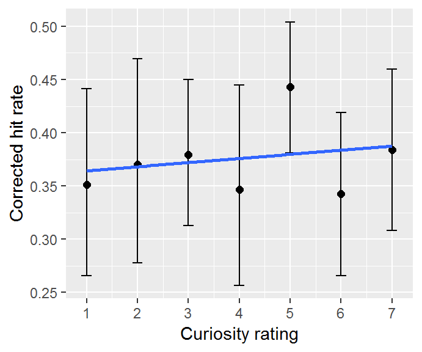

Figure 5. Mean accuracy for context memory as a function of curiosity rating.

### 4.1.1 Testing the relationship between mean accuracy of context memory and curiosity rating

Build models with context memory accuracy as $y$ and cexamine effects of curiosity rating by including it into the model and then comparing the model fits.

- `baseline.rating` is the model with only an intercept, showing no change in context memory as a function of curiosity rating.
- `rating.intercept` is the model with $\small CuriosityRating$ included, showing the effects of curiosity rating.
- `rating.slope` is the model allowing the slope (i.e., relationship between context memory and curiosity rating) varying across participants.

```
##                  Model df       AIC        BIC   logLik   Test   L.Ratio
## baseline.rating      1  3 -29.32661 -18.897217 17.66330
## rating.intercept     2  4 -27.65131 -13.745452 17.82565 1 vs 2 0.3246981
## rating.slope         3  6 -23.64340  -2.784618 17.82170 2 vs 3 0.0079067
##                  p-value
## baseline.rating
## rating.intercept  0.5688
## rating.slope      0.9961
```

### 4.1.2 Using normalised curiosity ratings.

```
##                  Model df       AIC       BIC   logLik   Test    L.Ratio
## baseline.rating      1  3 -29.32661 -18.89722 17.66330
## rating.intercept     2  4 -27.40756 -13.50170 17.70378 1 vs 2 0.08094965
## rating.slope         3  6 -23.61197  -2.75319 17.80599 2 vs 3 0.20441398
##                  p-value
## baseline.rating
## rating.intercept  0.7760
## rating.slope      0.9028
```

No effect of curiosity rating.

## 4.2 Does the relationship with curiosity rating depend on item order?

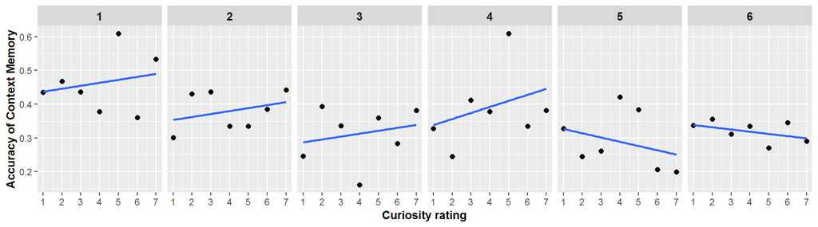

Figure 5. Mean accuracy across participants for context memory as a function of curiosity rating for each order at which the item was seen (I.e., 1st, 2nd, 3rd, etc.).

### 4.2.1 Testing the effect of item order

Build models with context memory accuracy as $y$ and examine effects of curioity rating and item order by comparing the models.

- `item.model.linear.1` is the model with $\small ItemOrder$ included (in addition to $\small CuriosityRating$), showing the effects of item order.
- `item.model.linear.2` is the model allowing the slope (i.e., relationship between context memory and item order) varying across participants.
- `item.model.linear.3` is the model with the interaction between $\small ItemOrders$ and $\small CuriosityRating$ included.
- `item.model.quad.1` and `item.model.quad.2` repectively included $\small ItemOrder^2$ and related random effects.
- `item.model.quad.3` included interaction between $\small ItemOrder^2$ and $\small CuriosityRating$ for inestigating whether the pattern changes as a function of *curiosity rating*.

```r
baseline.context <- lme(CorrContextAccuracy ~ 1, random = ~ 1|SubjectNo, data = Encoding.Recall.Old, method = "ML", control = list(msMaxIter = 500, opt = "optim", msVerbose=FALSE), na.action = na.exclude)

rating.intercept <- update(baseline.context, .~. + CuriosityRating)
rating.slope     <- update(rating.intercept, random = ~ 1 + CuriosityRating | SubjectNo)

item.model.linear.1     <- update(rating.slope, .~. + ItemOrder)
item.model.linear.2     <- update(item.model.linear.1, random = ~1+CuriosityRating+ItemOrder|SubjectNo)
item.model.linear.3     <- update(item.model.linear.2, .~. + ItemOrder : CuriosityRating)

# item.model.quad.1       <- update(item.model.linear.3, .~. + I(ItemOrder^2))
# item.model.quad.2       <- update(item.model.quad.1,   random = list(~1+CuriosityRating|SubjectNo, ~1+ItemOrder+I(ItemOrder^2)|SubjectNo)) # excluding this model because singularity issue (perhaps the model was getting too complex to be calculated)
# item.model.quad.3       <- update(item.model.quad.1,   .~. + I(ItemOrder^2) : CuriosityRating)

anova(baseline.context, rating.intercept, rating.slope, item.model.linear.1,item.model.linear.2,  item.model.linear.3)
```

```
##                     Model df      AIC      BIC    logLik   Test   L.Ratio
## baseline.context        1  3 1957.904 1973.696 -975.9519
## rating.intercept        2  4 1959.489 1980.545 -975.7443 1 vs 2  0.415087
## rating.slope            3  6 1963.011 1994.595 -975.5053 2 vs 3  0.478004
## item.model.linear.1     4  7 1951.247 1988.095 -968.6233 3 vs 4 13.764136
## item.model.linear.2     5 10 1956.847 2009.487 -968.4235 4 vs 5  0.399475
## item.model.linear.3     6 11 1957.755 2015.660 -967.8776 5 vs 6  1.091797
##                     p-value
## baseline.context
## rating.intercept     0.5194
## rating.slope         0.7874
## item.model.linear.1  0.0002
## item.model.linear.2  0.9404
## item.model.linear.3  0.2961
```

No effects of curiosity rating but all decreased significantly over item order.

### 4.2.2 Collapse the order and curiosity rating

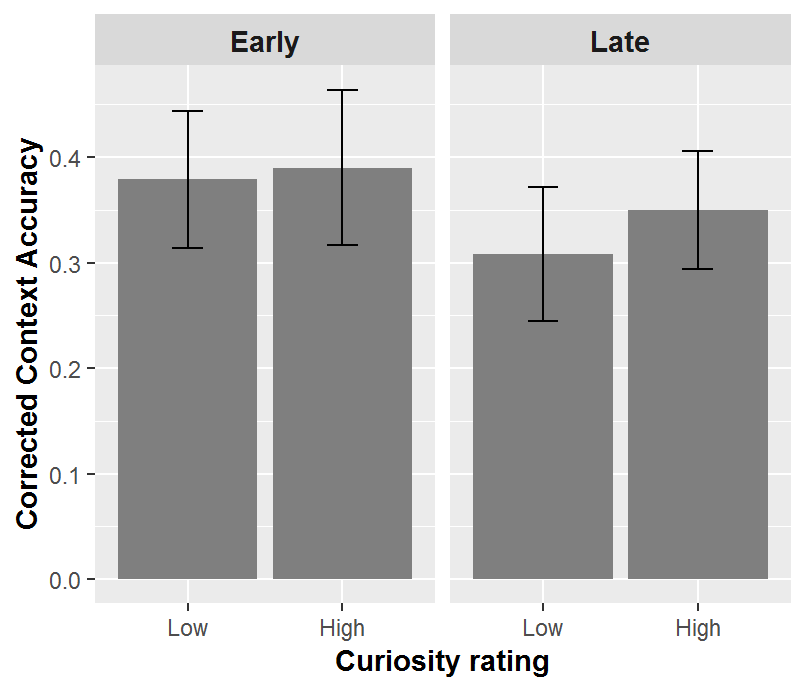

Figure 6. Mean hit rate as a function of item order (Early vs. Late) and curiosity (Low vs. High).

#### 4.2.2.1 Stats on it

```
##                  Model df       AIC       BIC   logLik   Test  L.Ratio
## baseline             1  5 -83.56494 -68.31566 46.78247
## curiosityModel       2  6 -82.79388 -64.49475 47.39694 1 vs 2 1.228940
## orderModel           3  7 -86.51068 -65.16168 50.25534 2 vs 3 5.716791
## interactionModel     4  8 -84.97841 -60.57956 50.48921 3 vs 4 0.467736
##                  p-value
## baseline
## curiosityModel    0.2676
## orderModel        0.0168
## interactionModel  0.4940
```

### 4.2.3 Try another way to calculate “High” and “Low” curiosity groups

> “High” - higher than mean; “Low” - lower than mean

#### 4.2.3.1 Compare “High” and “Low” groups

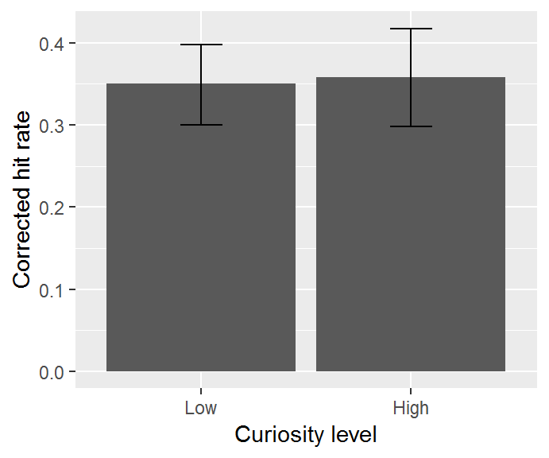

```
##
##  Paired t-test
##
## data:  CorrContextAccuracy by RatingGroup
## t = -0.28096, df = 39, p-value = 0.7802
## alternative hypothesis: true difference in means is not equal to 0
## 95 percent confidence interval:
##  -0.05719451  0.04324335
## sample estimates:
## mean of the differences
##            -0.006975583
```

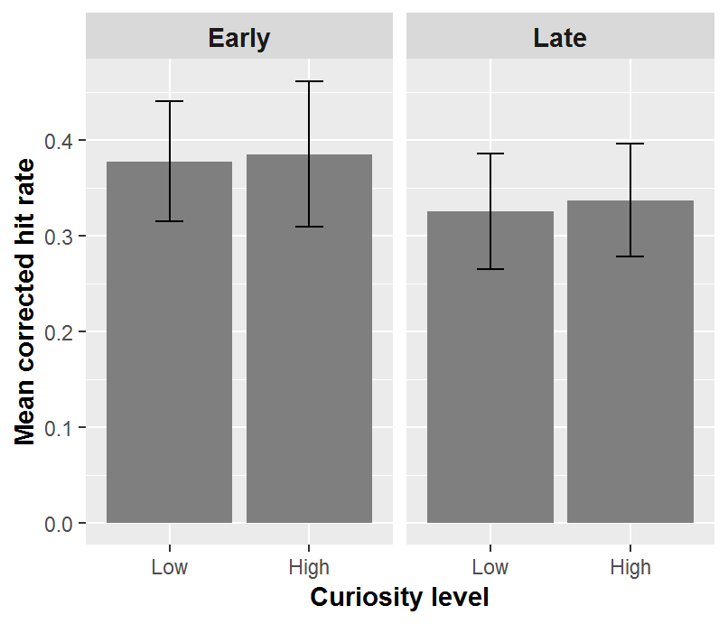

#### 4.2.3.2 Stats on it

```
##                  Model df       AIC       BIC   logLik   Test  L.Ratio
## baseline             1  5 -86.29729 -70.92142 48.14865
## curiosityModel       2  6 -84.45886 -66.00782 48.22943 1 vs 2 0.161567
## orderModel           3  7 -87.18581 -65.65960 50.59291 2 vs 3 4.726957
## interactionModel     4  8 -85.19305 -60.59166 50.59652 3 vs 4 0.007235
##                  p-value
## baseline
## curiosityModel    0.6877
## orderModel        0.0297
## interactionModel  0.9322
```

# 5 Curiosity and novelty

## 5.1 Testing the effects of curiosity rating and novelty together

Build models with context memory accuracy as $y$ and examine effects of curiosity rating and novelty together by including them into the model separately and then comparing the model fits.

```
##                   Model df       AIC        BIC   logLik   Test   L.Ratio
## baseline.rating       1  4 -27.32401 -13.418160 17.66201
## rating.intercept      2  5 -25.64831  -8.265993 17.82416 1 vs 2 0.3242959
## novelty.model.1       3  6 -25.13658  -4.277800 18.56829 2 vs 3 1.4882711
## interaction.model     4  7 -24.26135   0.073891 19.13068 3 vs 4 1.1247722
##                   p-value
## baseline.rating
## rating.intercept   0.5690
## novelty.model.1    0.2225
## interaction.model  0.2889
```

## 5.2 What about the other way around

```
##                   Model df      AIC      BIC    logLik   Test   L.Ratio
## baseline.context      1  3 1957.904 1973.696 -975.9519
## novelty.model.1       2  4 1959.840 1980.896 -975.9198 1 vs 2 0.0642094
## rating.model.1        3  5 1960.024 1986.344 -975.0120 2 vs 3 1.8155829
## rating.model.2        4 10 1969.067 2021.707 -974.5334 3 vs 4 0.9571626
## interaction.model     5 11 1969.307 2027.211 -973.6536 4 vs 5 1.7596454
##                   p-value
## baseline.context
## novelty.model.1    0.8000
## rating.model.1     0.1778
## rating.model.2     0.9659
## interaction.model  0.1847
```

## 5.3 Check the collapsed data

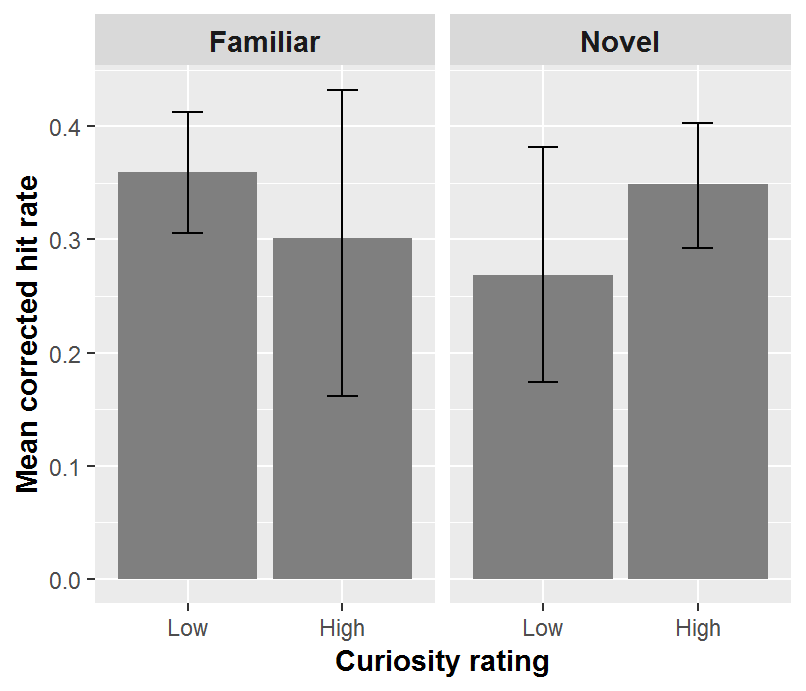

#### 5.3.0.1 Stats on it

```
##                  Model df       AIC       BIC   logLik   Test   L.Ratio
## baseline             1  5 -70.39683 -57.57509 40.19841
## curiosityModel       2  6 -68.39759 -53.01150 40.19879 1 vs 2 0.0007590
## noveltyModel         3  7 -67.39571 -49.44528 40.69786 2 vs 3 0.9981243
## interactionModel     4  8 -65.40944 -44.89465 40.70472 3 vs 4 0.0137229
##                  p-value
## baseline
## curiosityModel    0.9780
## noveltyModel      0.3178
## interactionModel  0.9067
```

Note the difference in sample size between conditions.

# 6 Curiosity effects in the *Novel* group

## 6.1 Mean accuracy of item memory as a function of curiosity rating

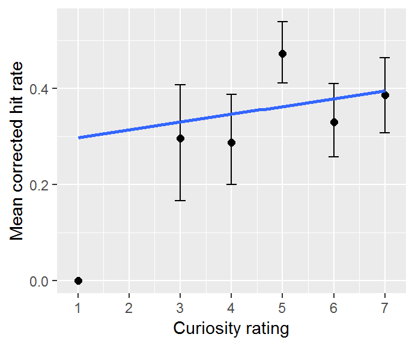